# Análise Fatorial

Matheus Nunes Paiva

2024-05-12

# 1 Introdução

```r
library(tidyverse)
library(readr)
library(FactoMineR)
library(factoextra)
library(DT)
library(ggplot2)
library(ggcorrplot)
library(corrplot)
library(gt)
library(psych)
library(GPArotation)
library(QuantPsyc)
```

# 2 Conjunto de dados

Este conjunto de dados resume um conjunto heterogêneo de características sobre artigos publicados pela Mashable em um período de dois anos.

Foram selecionadas apenas 15 variáveis e 400 observações para a análise fatorial, devido a grande extensão do conjunto de dados original e devido a problemas em rodar a análise fatorial com um número muito grande de observações.

|  | timedelta | n_tokens_title | average_token_length | kw_min_min | kw_max_min | kw_avg_min | kw_min_max | kw_max_max | kw_avg_max | kw_min_avg | kw_max_avg | kw_avg_avg | self_reference_min_shares | self_reference_max_shares | shares |
| --- | --- | --- | --- | --- | --- | --- | --- | --- | --- | --- | --- | --- | --- | --- | --- |
| 4451 | 652 | 10 | 4.95394736842 | 217 | 979 | 452.333333333 | 22300 | 617900 | 242600 | 2630.36693548 | 5836.93103448 | 4260.17478676 | 15200 | 15200 | 10700 |
| 12776 | 485 | 8 | 4.61479869423 | 4 | 795 | 234.833333333 | 4800 | 843300 | 274083.333333 | 1924.4379562 | 3256.26171384 | 2660.02762276 | 1400 | 4500 | 736 |
| 15095 | 441 | 6 | 4.75 | 4 | 217 | 110 | 16300 | 843300 | 259500 | 2068.52471483 | 3278.62516636 | 2785.58313323 | 7500 | 7500 | 1000 |
| 35112 | 79 | 8 | 0 | -1 | 573 | 81 | 0 | 843300 | 367811.111111 | 0 | 6024.53846154 | 3575.88656666 | 0 | 0 | 959 |
| 35375 | 76 | 10 | 0 | -1 | 12400 | 1700.82375 | 9900 | 843300 | 459750 | 2448.76923077 | 25300 | 7353.65933883 | 0 | 0 | 22500 |
| 22999 | 279 | 11 | 4.56870229008 | -1 | 546 | 213 | 6000 | 843300 | 275560 | 1643.13333333 | 6903.29032258 | 3817.61625713 | 640 | 640 | 826 |
| 30637 | 150 | 9 | 4.5 | -1 | 535 | 133 | 2700 | 843300 | 408125 | 1206 | 3494.08308808 | 2609.84324984 | 839 | 4400 | 1800 |
| 31678 | 133 | 7 | 4.71887550201 | -1 | 1800 | 312.07375 | 4600 | 843300 | 531500 | 1855.6969697 | 5332.01397744 | 3630.38190181 | 1600 | 4300 | 8800 |
| 10304 | 535 | 10 | 5.49382716049 | 4 | 852 | 209.888888889 | 852 | 843300 | 238572.444444 | 852 | 3303.98509208 | 2349.85941118 | 1400 | 2700 | 533 |
| 22182 | 294 | 10 | 4.83400809717 | -1 | 1100 | 291.575555556 | 1100 | 843300 | 460333.333333 | 1100 | 11040.25 | 5014.90057118 | 2600 | 2600 | 3800 |

[output cut: 390 more lines]

Iremos aplicar a o teste de Bartlett para verificar se a matriz de correlação é adequada para a análise fatorial.

```r
cortest.bartlett(cor(dados),n=nrow(dados))
```

```
## $chisq
## [1] 3141
##
## $p.value
## [1] 0
##
## $df
## [1] 105
```

Como o valor p do teste de Bartlett é menor que 0.05, rejeitamos a hipótese nula de que a matriz de correlação é uma matriz de identidade, indicando que existe ao menos uma correlação significativa entre as variáveis.

# 3 Matriz de correlação

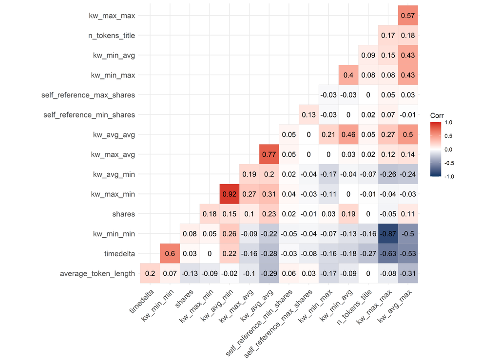

```r
 ggcorrplot(
            cor(dados),
            hc.order = T,
            type = "lower",
            lab = T,
            colors = c("#003262", "#FFFFFF", "#D21E1C")
          )
```

Pela matriz de correlação é possível observar que a maioria das variáveis não possuem correlação significativa entre si.

# 4 Análise Fatorial

```r
AFr<-fa(dados,nfactors=3, rotate = "varimax")
AFr
```

```
## Factor Analysis using method =  minres
## Call: fa(r = dados, nfactors = 3, rotate = "varimax")
## Standardized loadings (pattern matrix) based upon correlation matrix
##                             MR1   MR3   MR2     h2   u2 com
## timedelta                 -0.66 -0.27  0.04 0.5110 0.49 1.3
## n_tokens_title             0.21  0.09 -0.04 0.0516 0.95 1.4
## average_token_length      -0.07 -0.33 -0.04 0.1132 0.89 1.1
## kw_min_min                -0.89 -0.10  0.04 0.8075 0.19 1.0
## kw_max_min                -0.02  0.09  0.92 0.8497 0.15 1.0
## kw_avg_min                -0.25 -0.02  0.91 0.8923 0.11 1.2
## kw_min_max                 0.03  0.45 -0.23 0.2544 0.75 1.5
## kw_max_max                 0.93  0.15 -0.03 0.8879 0.11 1.1
## kw_avg_max                 0.49  0.64 -0.15 0.6745 0.33 2.0
## kw_min_avg                 0.06  0.56 -0.09 0.3216 0.68 1.1
## kw_max_avg                 0.07  0.41  0.34 0.2849 0.72 2.0
## kw_avg_avg                 0.14  0.86  0.35 0.8809 0.12 1.4
## self_reference_min_shares  0.07 -0.01  0.06 0.0083 0.99 2.0
## self_reference_max_shares  0.08 -0.03 -0.01 0.0065 0.99 1.3
## shares                    -0.11  0.26  0.15 0.0990 0.90 2.0
##
##                        MR1  MR3  MR2
## SS loadings           2.50 2.13 2.02
## Proportion Var        0.17 0.14 0.13
## Cumulative Var        0.17 0.31 0.44
## Proportion Explained  0.38 0.32 0.30
## Cumulative Proportion 0.38 0.70 1.00
##
## Mean item complexity =  1.4
## Test of the hypothesis that 3 factors are sufficient.
##
## df null model =  105  with the objective function =  7.99 with Chi Square =  3141
## df of  the model are 63  and the objective function was  2.11
##
## The root mean square of the residuals (RMSR) is  0.06
## The df corrected root mean square of the residuals is  0.07
##
## The harmonic n.obs is  400 with the empirical chi square  254.1  with prob <  8.7e-25
## The total n.obs was  400  with Likelihood Chi Square =  825  with prob <  3e-133
##
## Tucker Lewis Index of factoring reliability =  0.579
## RMSEA index =  0.174  and the 90 % confidence intervals are  0.164 0.185
## BIC =  447.6
## Fit based upon off diagonal values = 0.95
```

A primeira coisa a ser observada nesta saída é o valor de TLI, ou Tucker-Lewis Index, que é uma medida de ajuste do modelo. O TLI varia de 0 a 1, e valores acima de 0.9 indicam um bom ajuste do modelo. Neste caso o TLI é de aproximadamente 0.6, indicando que o modelo não se ajusta muito bem aos dados.

Porém supondo que o modelo se ajuste bem aos dados, a saída da análise fatorial nos fornece informações sobre os fatores extraídos, como a comunalidade, a variância explicada e a carga fatorial de cada variável em cada fator.

Para facilitar a interpretação irei extrair as cargas fatoriais maiores que 0.4. Cargas abaixo dessa magnitude são consideradas fracas e podem ser ignoradas.

# 5 Extraindo cargas maiores que 0.4

```r
print(AFr$loadings,cutoff = 0.4)
```

```
##
## Loadings:
##                           MR1    MR3    MR2
## timedelta                 -0.658
## n_tokens_title
## average_token_length
## kw_min_min                -0.892
## kw_max_min                               0.917
## kw_avg_min                               0.910
## kw_min_max                        0.449
## kw_max_max                 0.930
## kw_avg_max                 0.489  0.643
## kw_min_avg                        0.557
## kw_max_avg                        0.406
## kw_avg_avg                        0.860
## self_reference_min_shares
## self_reference_max_shares
## shares
##
##                  MR1   MR3   MR2
## SS loadings    2.495 2.129 2.019
## Proportion Var 0.166 0.142 0.135
## Cumulative Var 0.166 0.308 0.443
```

Pela saída acima, é possível observar que a maioria das variáveis possuem cargas fatoriais significativas em pelo menos um dos fatores extraídos. As cargas fatoriais variam de -1 a 1, e valores próximos de 1 indicam uma relação forte entre a variável e o fator, cargas próximas de 0 indicam que a variável não está relacionada ao fator e cargas próximas de -1 indicam uma relação negativa entre a variável e o fator.

# 6 Referências

Fernandes,Kelwin, Vinagre,Pedro, Cortez,Paulo, and Sernadela,Pedro. (2015). Online News Popularity. UCI Machine Learning Repository. https://doi.org/10.24432/C5NS3V.